# Airbnb_price_analysis

tonghua.lin@rutgers.edu

4/28/2024

## R Markdown

This is a new data set I found. It’s about the Airbnb lodges. The data set contains 29 columns and around 73000 rows. I want to use LDA to identify a lodge’s room type. Firstly, we have to read and clean up the data set.

```r
library(readr)
DataSet <- read_csv("Airbnb_Data.csv")
# Set the ID as the name of rows, exclude non-numerical columns
DataSet$id <- NULL
DataSet$property_type <- NULL
DataSet$amenities <- NULL
DataSet$description <- NULL
DataSet$name <- NULL
DataSet$thumbnail_url <- NULL
DataSet$neighbourhood <- NULL
DataSet$zipcode <-NULL
DataSet$bed_type <-NULL
DataSet$cancellation_policy <-NULL
DataSet$cleaning_fee <- NULL
DataSet$city <- NULL
DataSet$host_has_profile_pic <-NULL
DataSet$instant_bookable <-NULL


head(DataSet)
```

```
## # A tibble: 6 × 15
##   log_price room_type accommodates bathrooms first_review host_identity_verified
##       <dbl> <chr>            <dbl>     <dbl> <date>       <lgl>
## 1      5.01 Entire h…            3         1 2016-06-18   TRUE
## 2      5.13 Entire h…            7         1 2017-08-05   FALSE
## 3      4.98 Entire h…            5         1 2017-04-30   TRUE
## 4      6.62 Entire h…            4         1 NA           TRUE
## 5      4.74 Entire h…            2         1 2015-05-12   TRUE
## 6      4.44 Private …            2         1 2017-08-27   TRUE
## # ℹ 9 more variables: host_response_rate <chr>, host_since <date>,
## #   last_review <date>, latitude <dbl>, longitude <dbl>,
## #   number_of_reviews <dbl>, review_scores_rating <dbl>, bedrooms <dbl>,
## #   beds <dbl>
```

```r
# Check the NA data rows
sapply(DataSet, function(x) sum(is.na(x)))
```

```
##              log_price              room_type           accommodates
##                      0                      0                      0
##              bathrooms           first_review host_identity_verified
##                    200                  15864                    188
##     host_response_rate             host_since            last_review
##                  18299                    188                  15827
##               latitude              longitude      number_of_reviews
##                      0                      0                      0
##   review_scores_rating               bedrooms                   beds
##                  16722                     91                    131
```

From the NA check, we can see that there are lots of missing data. For bathrooms, we can set NA as 0. For first_review data, there are many NAs. That means they are never rented out, or no one give a review. Similar situation can be found in last_review, host_response_rate, review_score_rating. We can use the host_since date for the missing part. For the NA in host_since, we can see then number of missing rows is exactly same with host_identity_verified, and it’s small. Let’s drop these rows. For date variables, we can use 2017/11/01 as the baseline to calculate the interval. It can change the date variables to numerical variables.

```r
# Remove rows with na host_identity_verified
DataSet <- DataSet[!DataSet$room_type=="Shared room",]
DataSet <- DataSet[!is.na(DataSet$host_identity_verified),]
DataSet$host_identity_verified <-NULL
# Set na bathrooms to 0
DataSet$bathrooms[is.na(DataSet$bathrooms)] <- 0
# Use the host_since date for the na date
DataSet$first_review[is.na(DataSet$first_review)] <- DataSet$host_since[is.na(DataSet$first_review)]
DataSet$last_review[is.na(DataSet$last_review)] <- DataSet$host_since[is.na(DataSet$last_review)]
baslineDate <- as.Date('2017/11/01')
DataSet$first_review <- as.numeric(difftime(baslineDate, DataSet$first_review, units = "days"))
DataSet$last_review <- as.numeric(difftime(baslineDate, DataSet$last_review, units = "days"))
DataSet$host_since <- as.numeric(difftime(baslineDate, DataSet$host_since, units = "days"))
# Use mean for na host_response_rate and scores
DataSet$host_response_rate <- as.numeric(gsub("%", "", DataSet$host_response_rate))
DataSet$host_response_rate[is.na(DataSet$host_response_rate)] <- mean(DataSet$host_response_rate[!is.na(DataSet$host_response_rate)])
DataSet$review_scores_rating[is.na(DataSet$review_scores_rating)] <- mean(DataSet$review_scores_rating[!is.na(DataSet$review_scores_rating)])
DataSet$bedrooms[is.na(DataSet$bedrooms)] <- 1
DataSet$beds[is.na(DataSet$beds)] <- round(mean(DataSet$beds[!is.na(DataSet$beds)]))
sapply(DataSet, function(x) sum(is.na(x)))
```

```
##            log_price            room_type         accommodates
##                    0                    0                    0
##            bathrooms         first_review   host_response_rate
##                    0                    0                    0
##           host_since          last_review             latitude
##                    0                    0                    0
##            longitude    number_of_reviews review_scores_rating
##                    0                    0                    0
##             bedrooms                 beds
##                    0                    0
```

After clean up the na data, we can set the room_type as numerical variable and start LDA.

```r
library(MASS)
DataSet_raw <- cbind(DataSet, as.numeric(as.factor(DataSet$room_type))-1)
DataSet_raw$room_type<-NULL
colnames(DataSet_raw)[14] <- "room_type"
str(DataSet_raw)
```

```
## 'data.frame':    71762 obs. of  14 variables:
##  $ log_price           : num  5.01 5.13 4.98 6.62 4.74 ...
##  $ accommodates        : num  3 7 5 4 2 2 3 2 2 2 ...
##  $ bathrooms           : num  1 1 1 1 1 1 1 1 1 1 ...
##  $ first_review        : num  501 88 185 927 904 66 236 320 627 212 ...
##  $ host_response_rate  : num  94.5 100 100 94.5 100 ...
##  $ host_since          : num  2046 135 372 927 976 ...
##  $ last_review         : num  471 39 48 927 283 57 194 203 38 199 ...
##  $ latitude            : num  40.7 40.8 40.8 37.8 38.9 ...
##  $ longitude           : num  -74 -74 -73.9 -122.4 -77 ...
##  $ number_of_reviews   : num  2 6 10 0 4 3 15 9 159 2 ...
##  $ review_scores_rating: num  100 93 92 94.1 40 ...
##  $ bedrooms            : num  1 3 1 2 0 1 1 1 1 1 ...
##  $ beds                : num  1 3 3 2 1 1 1 1 1 1 ...
##  $ room_type           : num  0 0 0 0 0 1 0 0 1 1 ...
```

```r
smp_size_raw <- floor(0.75 * nrow(DataSet_raw))
train_ind_raw <- sample(nrow(DataSet_raw), size = smp_size_raw)
train_raw <- as.data.frame(DataSet_raw[train_ind_raw, ])
test_raw <- as.data.frame(DataSet_raw[-train_ind_raw, ])
DataSet_raw.lda <- lda(formula = train_raw$room_type ~ ., data = train_raw)
summary(DataSet_raw.lda)
```

```
##         Length Class  Mode
## prior    2     -none- numeric
## counts   2     -none- numeric
## means   26     -none- numeric
## scaling 13     -none- numeric
## lev      2     -none- character
## svd      1     -none- numeric
## N        1     -none- numeric
## call     3     -none- call
## terms    3     terms  call
## xlevels  0     -none- list
```

```r
print(DataSet_raw.lda)
```

```
## Call:
## lda(train_raw$room_type ~ ., data = train_raw)
##
## Prior probabilities of groups:
##         0         1
## 0.5748871 0.4251129
##
## Group means:
##   log_price accommodates bathrooms first_review host_response_rate host_since
## 0  5.167454     4.073527  1.306244     759.3967           94.75352   1241.653
## 1  4.326651     1.988462  1.125940     723.4404           94.10956   1158.707
##   last_review latitude longitude number_of_reviews review_scores_rating
## 0    397.4489 38.31879 -93.34715          21.70114             94.25634
## 1    414.4347 38.66493 -90.87900          20.62045             93.89290
##   bedrooms    beds
## 0 1.454284 2.10394
## 1 1.027404 1.17417
##
## Coefficients of linear discriminants:
##                                LD1
## log_price            -1.502696e+00
## accommodates         -3.238840e-01
## bathrooms             5.001737e-01
## first_review         -5.960503e-05
## host_response_rate   -2.557410e-03
## host_since           -1.589891e-04
## last_review           2.877385e-04
## latitude              8.555256e-02
## longitude            -8.357599e-03
## number_of_reviews     1.519388e-03
## review_scores_rating  7.446249e-04
## bedrooms              5.096374e-01
## beds                 -1.119113e-01
```

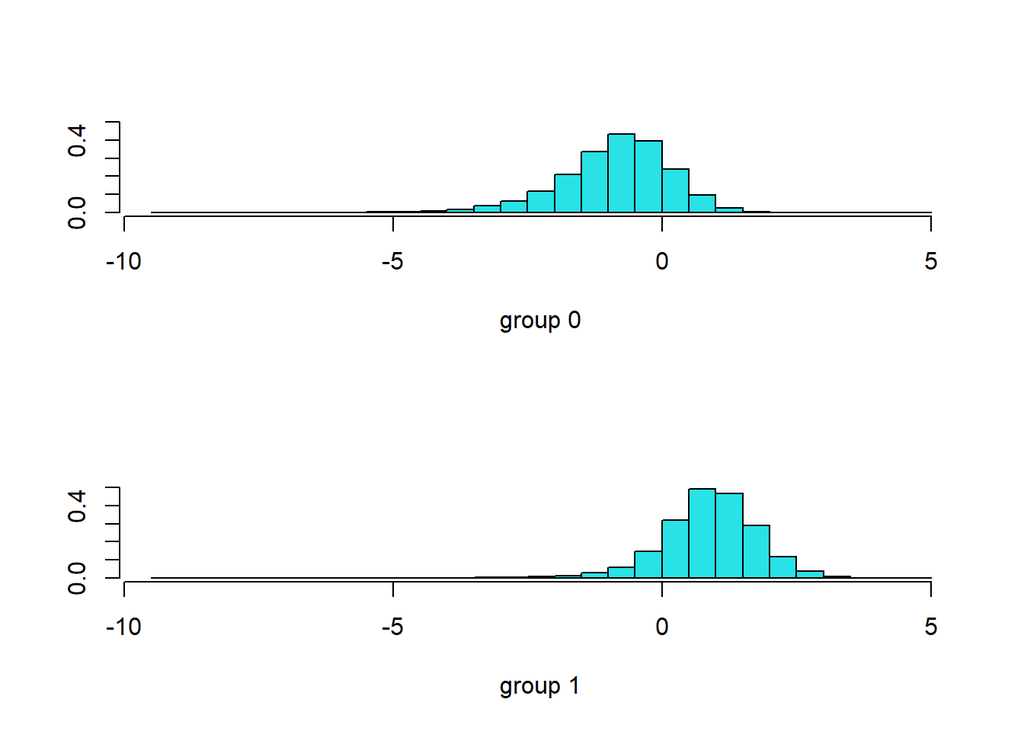

```r
plot(DataSet_raw.lda)
```

From the result, we can see that group 0 and group 1, namely Entire home/apartment and private room, can not be differentiated very clearly. Still, they have some differences. By the probabilities of groups, we can get about 57% rows distinguished. We also can check the means of different variables’ differences. Let’s predict the test set and check the accuracy.

```r
DataSet_raw.lda.predict <- predict(DataSet_raw.lda, newdata = test_raw)
DataSet_raw.lda.predict$class[1:100]
```

```
##   [1] 0 1 1 0 1 1 1 0 0 1 1 0 1 1 1 0 0 0 0 1 0 0 0 1 1 1 0 1 0 0 0 0 0 0 0 1 1
##  [38] 0 0 0 1 1 0 0 1 0 0 0 0 0 0 1 0 1 1 0 0 1 0 1 0 0 0 0 1 0 0 0 1 1 1 0 0 0
##  [75] 0 0 0 0 0 0 0 0 1 0 0 1 0 0 1 0 0 1 1 0 0 0 1 1 0 0
## Levels: 0 1
```

```r
DataSet_raw.lda.predict$x[1:100]
```

```
##   [1] -0.50226982  0.41019439  0.99860817 -1.53848945  1.99468476  2.11657886
##   [7]  1.26533403 -0.49632273 -0.28390823  0.99570528  0.36886553 -0.29756385
##  [13]  0.41419832  1.97761990  1.47063722 -1.08832710  0.26294734 -1.69913015
##  [19] -0.85530897  0.40808742 -1.15133888 -1.46302023  0.17910804  2.06304512
##  [25]  0.85071650  1.19199061 -0.97679244  0.30855986 -2.46008834 -0.27563467
##  [31] -1.03450588 -2.12082201  0.03397171 -0.47466569 -1.88516441  1.62362557
##  [37]  0.44956062 -0.35326179  0.18309388 -2.86656835  1.09633407  0.46678568
##  [43] -0.35950656 -1.48128058  0.33304617 -1.61329750 -0.67587868 -1.36079968
##  [49]  0.24605895 -0.08421959 -0.48423950  0.70430819  0.12576180  1.05619045
##  [55]  0.32690961 -1.06977397 -0.08282403  1.11319247 -0.47134845  0.64480927
##  [61] -1.76561982 -1.04090651 -2.68263207 -0.91636763  1.76666497 -0.14233174
##  [67] -1.73479426 -0.43554934  1.22161574  1.40757049  1.09871337 -0.47876973
##  [73] -1.32688786  0.08507532 -2.03648774 -1.01942452 -0.42831365 -0.17594645
##  [79]  0.03930600  0.09614277 -0.21966558 -2.31278505  0.76740166 -1.91926248
##  [85] -1.80931005  2.42516387 -1.13604844 -0.80885814  0.47599658 -1.55483751
##  [91]  0.20232211  0.41060316  1.72174510 -1.25293782 -0.45560818 -1.06372694
##  [97]  0.40837166  2.12584454 -0.66123720 -1.60928971
```

We can check the accuracy by the plot.

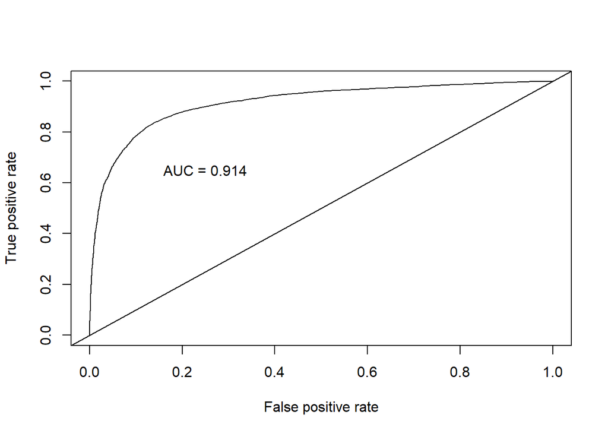

```r
# Get the posteriors as a dataframe.
library(ROCR)
library(dplyr)
library(ggplot2)
library(memisc)
DataSet_raw.lda.predict.posteriors <- as.data.frame(DataSet_raw.lda.predict$posterior)

pred <- prediction(DataSet_raw.lda.predict.posteriors[,2], test_raw$room_type)
roc.perf = performance(pred, measure = "tpr", x.measure = "fpr")
auc.train <- performance(pred, measure = "auc")
auc.train <- auc.train@y.values
plot(roc.perf)
abline(a=0, b= 1)
text(x = .25, y = .65 ,paste("AUC = ", round(auc.train[[1]],3), sep = ""))
```